# Optimal Treatment Analysis

## Outcome Variable

**Outcome Variable:** haz

## Predictor Variables

**Intervention Variable:** feducyrs

**Adjustment Set:**

- arm
- W_mage
- meducyrs
- hhwealth_quart
- W_mhtcm
- W_mwtkg
- W_mbmi
- W_gagebrth
- W_birthwt
- W_birthlen
- single
- impsan
- delta_W_mage
- delta_meducyrs
- delta_hhwealth_quart
- delta_W_mhtcm
- delta_W_mwtkg
- delta_W_mbmi
- delta_W_gagebrth
- delta_W_birthwt
- delta_W_birthlen
- delta_single
- delta_impsan

## Stratifying Variables

The analysis was stratified on these variable(s):

- agecat
- studyid
- country

## Data Summary

| agecat | studyid | country | feducyrs | n_cell | n |
| --- | --- | --- | --- | --- | --- |
| Birth | ki0047075b-MAL-ED | BANGLADESH | High | 47 | 129 |
| Birth | ki0047075b-MAL-ED | BANGLADESH | Low | 36 | 129 |
| Birth | ki0047075b-MAL-ED | BANGLADESH | Medium | 46 | 129 |
| Birth | ki0047075b-MAL-ED | INDIA | High | 7 | 24 |
| Birth | ki0047075b-MAL-ED | INDIA | Low | 14 | 24 |
| Birth | ki0047075b-MAL-ED | INDIA | Medium | 3 | 24 |
| Birth | ki0047075b-MAL-ED | NEPAL | High | 3 | 10 |
| Birth | ki0047075b-MAL-ED | NEPAL | Low | 4 | 10 |
| Birth | ki0047075b-MAL-ED | NEPAL | Medium | 3 | 10 |
| Birth | ki0047075b-MAL-ED | PERU | High | 86 | 194 |
| Birth | ki0047075b-MAL-ED | PERU | Low | 58 | 194 |
| Birth | ki0047075b-MAL-ED | PERU | Medium | 50 | 194 |
| Birth | ki0047075b-MAL-ED | SOUTH AFRICA | High | 10 | 33 |
| Birth | ki0047075b-MAL-ED | SOUTH AFRICA | Low | 14 | 33 |
| Birth | ki0047075b-MAL-ED | SOUTH AFRICA | Medium | 9 | 33 |
| Birth | ki0047075b-MAL-ED | TANZANIA, UNITED REPUBLIC OF | High | 66 | 103 |
| Birth | ki0047075b-MAL-ED | TANZANIA, UNITED REPUBLIC OF | Low | 27 | 103 |
| Birth | ki0047075b-MAL-ED | TANZANIA, UNITED REPUBLIC OF | Medium | 10 | 103 |
| Birth | ki1000304b-SAS-CompFeed | INDIA | High | 299 | 1249 |
| Birth | ki1000304b-SAS-CompFeed | INDIA | Low | 543 | 1249 |
| Birth | ki1000304b-SAS-CompFeed | INDIA | Medium | 407 | 1249 |
| Birth | ki1017093b-PROVIDE | BANGLADESH | High | 163 | 539 |
| Birth | ki1017093b-PROVIDE | BANGLADESH | Low | 187 | 539 |
| Birth | ki1017093b-PROVIDE | BANGLADESH | Medium | 189 | 539 |
| Birth | ki1017093c-NIH-Crypto | BANGLADESH | High | 284 | 732 |
| Birth | ki1017093c-NIH-Crypto | BANGLADESH | Low | 235 | 732 |
| Birth | ki1017093c-NIH-Crypto | BANGLADESH | Medium | 213 | 732 |
| Birth | ki1113344-GMS-Nepal | NEPAL | High | 172 | 694 |
| Birth | ki1113344-GMS-Nepal | NEPAL | Low | 296 | 694 |
| Birth | ki1113344-GMS-Nepal | NEPAL | Medium | 226 | 694 |

[output cut: 135 more lines]

The following strata were considered:

- agecat: 24 months, studyid: ki0047075b-MAL-ED, country: BANGLADESH
- agecat: 24 months, studyid: ki0047075b-MAL-ED, country: INDIA
- agecat: 24 months, studyid: ki0047075b-MAL-ED, country: NEPAL
- agecat: 24 months, studyid: ki0047075b-MAL-ED, country: PERU
- agecat: 24 months, studyid: ki0047075b-MAL-ED, country: SOUTH AFRICA
- agecat: 24 months, studyid: ki0047075b-MAL-ED, country: TANZANIA, UNITED REPUBLIC OF
- agecat: 24 months, studyid: ki1017093b-PROVIDE, country: BANGLADESH
- agecat: 24 months, studyid: ki1017093c-NIH-Crypto, country: BANGLADESH
- agecat: 24 months, studyid: ki1066203-TanzaniaChild2, country: TANZANIA, UNITED REPUBLIC OF
- agecat: 24 months, studyid: ki1113344-GMS-Nepal, country: NEPAL
- agecat: 24 months, studyid: ki1119695-PROBIT, country: BELARUS
- agecat: 24 months, studyid: ki1126311-ZVITAMBO, country: ZIMBABWE
- agecat: 24 months, studyid: ki1135781-COHORTS, country: GUATEMALA
- agecat: 24 months, studyid: ki1135781-COHORTS, country: INDIA
- agecat: 24 months, studyid: ki1135781-COHORTS, country: PHILIPPINES
- agecat: 24 months, studyid: ki1148112-LCNI-5, country: MALAWI
- agecat: 24 months, studyid: kiGH5241-JiVitA-3, country: BANGLADESH
- agecat: 24 months, studyid: kiGH5241-JiVitA-4, country: BANGLADESH
- agecat: 6 months, studyid: ki0047075b-MAL-ED, country: BANGLADESH
- agecat: 6 months, studyid: ki0047075b-MAL-ED, country: INDIA
- agecat: 6 months, studyid: ki0047075b-MAL-ED, country: NEPAL
- agecat: 6 months, studyid: ki0047075b-MAL-ED, country: PERU
- agecat: 6 months, studyid: ki0047075b-MAL-ED, country: SOUTH AFRICA
- agecat: 6 months, studyid: ki0047075b-MAL-ED, country: TANZANIA, UNITED REPUBLIC OF
- agecat: 6 months, studyid: ki1000304b-SAS-CompFeed, country: INDIA
- agecat: 6 months, studyid: ki1000304b-SAS-FoodSuppl, country: INDIA
- agecat: 6 months, studyid: ki1017093b-PROVIDE, country: BANGLADESH
- agecat: 6 months, studyid: ki1017093c-NIH-Crypto, country: BANGLADESH
- agecat: 6 months, studyid: ki1066203-TanzaniaChild2, country: TANZANIA, UNITED REPUBLIC OF
- agecat: 6 months, studyid: ki1113344-GMS-Nepal, country: NEPAL
- agecat: 6 months, studyid: ki1119695-PROBIT, country: BELARUS
- agecat: 6 months, studyid: ki1126311-ZVITAMBO, country: ZIMBABWE
- agecat: 6 months, studyid: ki1135781-COHORTS, country: GUATEMALA
- agecat: 6 months, studyid: ki1135781-COHORTS, country: INDIA
- agecat: 6 months, studyid: ki1135781-COHORTS, country: PHILIPPINES
- agecat: 6 months, studyid: ki1148112-LCNI-5, country: MALAWI
- agecat: 6 months, studyid: kiGH5241-JiVitA-3, country: BANGLADESH
- agecat: 6 months, studyid: kiGH5241-JiVitA-4, country: BANGLADESH
- agecat: Birth, studyid: ki0047075b-MAL-ED, country: BANGLADESH
- agecat: Birth, studyid: ki0047075b-MAL-ED, country: INDIA
- agecat: Birth, studyid: ki0047075b-MAL-ED, country: NEPAL
- agecat: Birth, studyid: ki0047075b-MAL-ED, country: PERU
- agecat: Birth, studyid: ki0047075b-MAL-ED, country: SOUTH AFRICA
- agecat: Birth, studyid: ki0047075b-MAL-ED, country: TANZANIA, UNITED REPUBLIC OF
- agecat: Birth, studyid: ki1000304b-SAS-CompFeed, country: INDIA
- agecat: Birth, studyid: ki1017093b-PROVIDE, country: BANGLADESH
- agecat: Birth, studyid: ki1017093c-NIH-Crypto, country: BANGLADESH
- agecat: Birth, studyid: ki1113344-GMS-Nepal, country: NEPAL
- agecat: Birth, studyid: ki1119695-PROBIT, country: BELARUS
- agecat: Birth, studyid: ki1126311-ZVITAMBO, country: ZIMBABWE
- agecat: Birth, studyid: ki1135781-COHORTS, country: GUATEMALA
- agecat: Birth, studyid: ki1135781-COHORTS, country: INDIA
- agecat: Birth, studyid: ki1135781-COHORTS, country: PHILIPPINES
- agecat: Birth, studyid: kiGH5241-JiVitA-3, country: BANGLADESH
- agecat: Birth, studyid: kiGH5241-JiVitA-4, country: BANGLADESH

### Dropped Strata

Some strata were dropped due to rare outcomes:

- agecat: Birth, studyid: ki0047075b-MAL-ED, country: INDIA
- agecat: Birth, studyid: ki0047075b-MAL-ED, country: NEPAL
- agecat: 24 months, studyid: ki1066203-TanzaniaChild2, country: TANZANIA, UNITED REPUBLIC OF

## Methods Detail

We’re interested in the causal parameters $E[Y_a]$ for all values of $a \in \mathcal{A}$. These parameters represent the mean outcome if, possibly contrary to fact, we intervened to set all units to have $A=a$. Under the randomization and positivity assumptions, these are identified by the statistical parameters $\psi_a=E_W[E_{Y|A,W}(Y|A=a,W)]$. In addition, we’re interested in the mean of $Y$, $E[Y]$ under no intervention (the observed mean). We will estimate these parameters by using SuperLearner to fit the relevant likelihood factors – $E_{Y|A,W}(Y|A=a,W)$ and $p(A=a|W)$, and then updating our likelihood fit using a joint TMLE.

For unadjusted analyses ($W=\{\}$), initial likelihoods were estimated using Lrnr_glm to estimate the simple $E(Y|A)$ and Lrnr_mean to estimate $p(A)$. For adjusted analyses, a small library containing Lrnr_glmnet, Lrnr_xgboost, and Lrnr_mean was used.

Having estimated these parameters, we will then use the delta method to estimate relative risks and attributable risks relative to a prespecified baseline level of $A$.

# Results Detail

## Results Plots

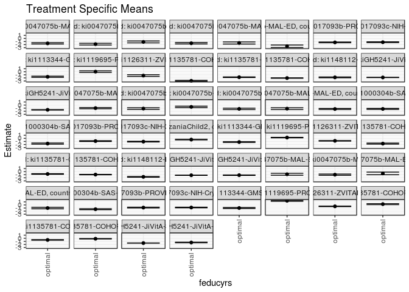

## Results Table

### Parameter: TSM

| agecat | studyid | country | intervention_level | baseline_level | estimate | ci_lower | ci_upper |
| --- | --- | --- | --- | --- | --- | --- | --- |
| Birth | ki0047075b-MAL-ED | BANGLADESH | optimal | observed | -0.8493306 | -1.1707041 | -0.5279571 |
| Birth | ki0047075b-MAL-ED | PERU | optimal | observed | -0.9895844 | -1.2006362 | -0.7785327 |
| Birth | ki0047075b-MAL-ED | SOUTH AFRICA | optimal | observed | -0.5759627 | -1.0105382 | -0.1413872 |
| Birth | ki0047075b-MAL-ED | TANZANIA, UNITED REPUBLIC OF | optimal | observed | -1.0074798 | -1.2587406 | -0.7562190 |
| Birth | ki1000304b-SAS-CompFeed | INDIA | optimal | observed | -1.3795721 | -1.5425683 | -1.2165759 |
| Birth | ki1017093b-PROVIDE | BANGLADESH | optimal | observed | -0.8582360 | -0.9895395 | -0.7269324 |
| Birth | ki1017093c-NIH-Crypto | BANGLADESH | optimal | observed | -0.8316043 | -0.9404989 | -0.7227098 |
| Birth | ki1113344-GMS-Nepal | NEPAL | optimal | observed | -0.9984601 | -1.1595974 | -0.8373228 |
| Birth | ki1119695-PROBIT | BELARUS | optimal | observed | 1.3582187 | 1.1895726 | 1.5268648 |
| Birth | ki1126311-ZVITAMBO | ZIMBABWE | optimal | observed | -0.4548309 | -0.5337202 | -0.3759416 |
| Birth | ki1135781-COHORTS | GUATEMALA | optimal | observed | 0.2640327 | 0.0927663 | 0.4352990 |
| Birth | ki1135781-COHORTS | INDIA | optimal | observed | -0.5526603 | -0.6488599 | -0.4564606 |
| Birth | ki1135781-COHORTS | PHILIPPINES | optimal | observed | -0.1693533 | -0.2394380 | -0.0992687 |
| Birth | kiGH5241-JiVitA-3 | BANGLADESH | optimal | observed | -1.5653270 | -1.5970693 | -1.5335846 |
| Birth | kiGH5241-JiVitA-4 | BANGLADESH | optimal | observed | -1.3868210 | -1.4875090 | -1.2861331 |
| 6 months | ki0047075b-MAL-ED | BANGLADESH | optimal | observed | -0.9993432 | -1.2009365 | -0.7977500 |
| 6 months | ki0047075b-MAL-ED | INDIA | optimal | observed | -1.1449604 | -1.4164382 | -0.8734826 |
| 6 months | ki0047075b-MAL-ED | NEPAL | optimal | observed | -0.6046827 | -0.8415824 | -0.3677829 |
| 6 months | ki0047075b-MAL-ED | PERU | optimal | observed | -1.2403734 | -1.4752478 | -1.0054991 |
| 6 months | ki0047075b-MAL-ED | SOUTH AFRICA | optimal | observed | -1.1694895 | -1.4695475 | -0.8694315 |
| 6 months | ki0047075b-MAL-ED | TANZANIA, UNITED REPUBLIC OF | optimal | observed | -1.2828247 | -1.4495515 | -1.1160980 |
| 6 months | ki1000304b-SAS-CompFeed | INDIA | optimal | observed | -1.2528766 | -1.4165709 | -1.0891822 |
| 6 months | ki1000304b-SAS-FoodSuppl | INDIA | optimal | observed | -1.7012469 | -1.9031249 | -1.4993689 |
| 6 months | ki1017093b-PROVIDE | BANGLADESH | optimal | observed | -0.8926648 | -1.0161660 | -0.7691636 |
| 6 months | ki1017093c-NIH-Crypto | BANGLADESH | optimal | observed | -1.0693760 | -1.1822441 | -0.9565079 |
| 6 months | ki1066203-TanzaniaChild2 | TANZANIA, UNITED REPUBLIC OF | optimal | observed | -0.4050267 | -0.5145150 | -0.2955383 |
| 6 months | ki1113344-GMS-Nepal | NEPAL | optimal | observed | -1.2013041 | -1.3615109 | -1.0410972 |
| 6 months | ki1119695-PROBIT | BELARUS | optimal | observed | 0.2518184 | 0.1656383 | 0.3379985 |
| 6 months | ki1126311-ZVITAMBO | ZIMBABWE | optimal | observed | -0.8066000 | -0.9014971 | -0.7117029 |
| 6 months | ki1135781-COHORTS | GUATEMALA | optimal | observed | -1.7108443 | -1.8870082 | -1.5346804 |
| 6 months | ki1135781-COHORTS | INDIA | optimal | observed | -0.7595112 | -0.8497220 | -0.6693003 |
| 6 months | ki1135781-COHORTS | PHILIPPINES | optimal | observed | -0.9579907 | -1.0349903 | -0.8809910 |
| 6 months | ki1148112-LCNI-5 | MALAWI | optimal | observed | -1.6882094 | -1.8161529 | -1.5602658 |
| 6 months | kiGH5241-JiVitA-3 | BANGLADESH | optimal | observed | -1.1696412 | -1.2112621 | -1.1280203 |
| 6 months | kiGH5241-JiVitA-4 | BANGLADESH | optimal | observed | -1.1461284 | -1.2269960 | -1.0652609 |
| 24 months | ki0047075b-MAL-ED | BANGLADESH | optimal | observed | -1.5977074 | -1.8110621 | -1.3843527 |
| 24 months | ki0047075b-MAL-ED | INDIA | optimal | observed | -1.8396345 | -2.1210675 | -1.5582016 |
| 24 months | ki0047075b-MAL-ED | NEPAL | optimal | observed | -1.1266819 | -1.4390153 | -0.8143485 |
| 24 months | ki0047075b-MAL-ED | PERU | optimal | observed | -1.5597675 | -1.7923727 | -1.3271624 |
| 24 months | ki0047075b-MAL-ED | SOUTH AFRICA | optimal | observed | -1.4720503 | -1.8155225 | -1.1285780 |
| 24 months | ki0047075b-MAL-ED | TANZANIA, UNITED REPUBLIC OF | optimal | observed | -2.5366859 | -2.9526884 | -2.1206835 |
| 24 months | ki1017093b-PROVIDE | BANGLADESH | optimal | observed | -1.2831607 | -1.4111677 | -1.1551537 |
| 24 months | ki1017093c-NIH-Crypto | BANGLADESH | optimal | observed | -1.2214781 | -1.3534033 | -1.0895529 |
| 24 months | ki1113344-GMS-Nepal | NEPAL | optimal | observed | -1.6474388 | -1.8473229 | -1.4475548 |
| 24 months | ki1119695-PROBIT | BELARUS | optimal | observed | 0.0360358 | -0.2257184 | 0.2977900 |
| 24 months | ki1126311-ZVITAMBO | ZIMBABWE | optimal | observed | -1.2448648 | -1.5185137 | -0.9712158 |
| 24 months | ki1135781-COHORTS | GUATEMALA | optimal | observed | -2.9424917 | -3.0935681 | -2.7914153 |
| 24 months | ki1135781-COHORTS | INDIA | optimal | observed | -1.7743232 | -1.8691960 | -1.6794504 |
| 24 months | ki1135781-COHORTS | PHILIPPINES | optimal | observed | -2.0455702 | -2.1263339 | -1.9648066 |
| 24 months | ki1148112-LCNI-5 | MALAWI | optimal | observed | -1.8238788 | -1.9580095 | -1.6897481 |
| 24 months | kiGH5241-JiVitA-3 | BANGLADESH | optimal | observed | -1.8522106 | -1.9027903 | -1.8016309 |
| 24 months | kiGH5241-JiVitA-4 | BANGLADESH | optimal | observed | -1.5451014 | -1.6150304 | -1.4751725 |

### Parameter: E(Y)

| agecat | studyid | country | intervention_level | baseline_level | estimate | ci_lower | ci_upper |
| --- | --- | --- | --- | --- | --- | --- | --- |
| Birth | ki0047075b-MAL-ED | BANGLADESH | observed | observed | -1.1609302 | -1.3461119 | -0.9757486 |
| Birth | ki0047075b-MAL-ED | PERU | observed | observed | -0.8645361 | -0.9887014 | -0.7403707 |
| Birth | ki0047075b-MAL-ED | SOUTH AFRICA | observed | observed | -0.5575758 | -0.8541170 | -0.2610345 |
| Birth | ki0047075b-MAL-ED | TANZANIA, UNITED REPUBLIC OF | observed | observed | -1.0906796 | -1.3207118 | -0.8606474 |
| Birth | ki1000304b-SAS-CompFeed | INDIA | observed | observed | -1.4300160 | -1.5090211 | -1.3510109 |
| Birth | ki1017093b-PROVIDE | BANGLADESH | observed | observed | -0.8851020 | -0.9601332 | -0.8100709 |
| Birth | ki1017093c-NIH-Crypto | BANGLADESH | observed | observed | -0.9094945 | -0.9809370 | -0.8380521 |
| Birth | ki1113344-GMS-Nepal | NEPAL | observed | observed | -1.0885159 | -1.1686181 | -1.0084136 |
| Birth | ki1119695-PROBIT | BELARUS | observed | observed | 1.3357134 | 1.1759964 | 1.4954304 |
| Birth | ki1126311-ZVITAMBO | ZIMBABWE | observed | observed | -0.4977261 | -0.5185420 | -0.4769102 |
| Birth | ki1135781-COHORTS | GUATEMALA | observed | observed | 0.1369030 | 0.0500914 | 0.2237146 |
| Birth | ki1135781-COHORTS | INDIA | observed | observed | -0.6011965 | -0.6594222 | -0.5429708 |
| Birth | ki1135781-COHORTS | PHILIPPINES | observed | observed | -0.2407379 | -0.2807613 | -0.2007145 |
| Birth | kiGH5241-JiVitA-3 | BANGLADESH | observed | observed | -1.5843618 | -1.6039583 | -1.5647653 |
| Birth | kiGH5241-JiVitA-4 | BANGLADESH | observed | observed | -1.5242226 | -1.5742923 | -1.4741529 |
| 6 months | ki0047075b-MAL-ED | BANGLADESH | observed | observed | -1.0786869 | -1.2229595 | -0.9344142 |
| 6 months | ki0047075b-MAL-ED | INDIA | observed | observed | -1.0820652 | -1.2263805 | -0.9377499 |
| 6 months | ki0047075b-MAL-ED | NEPAL | observed | observed | -0.6179474 | -0.8011766 | -0.4347182 |
| 6 months | ki0047075b-MAL-ED | PERU | observed | observed | -1.3208519 | -1.4383850 | -1.2033189 |
| 6 months | ki0047075b-MAL-ED | SOUTH AFRICA | observed | observed | -0.9829167 | -1.1753367 | -0.7904967 |
| 6 months | ki0047075b-MAL-ED | TANZANIA, UNITED REPUBLIC OF | observed | observed | -1.3283002 | -1.4654809 | -1.1911194 |
| 6 months | ki1000304b-SAS-CompFeed | INDIA | observed | observed | -1.4006377 | -1.4802862 | -1.3209891 |
| 6 months | ki1000304b-SAS-FoodSuppl | INDIA | observed | observed | -1.8986842 | -2.0118892 | -1.7854792 |
| 6 months | ki1017093b-PROVIDE | BANGLADESH | observed | observed | -1.0916915 | -1.1661176 | -1.0172654 |
| 6 months | ki1017093c-NIH-Crypto | BANGLADESH | observed | observed | -1.1986783 | -1.2700937 | -1.1272630 |
| 6 months | ki1066203-TanzaniaChild2 | TANZANIA, UNITED REPUBLIC OF | observed | observed | -0.5442042 | -0.5932639 | -0.4951446 |
| 6 months | ki1113344-GMS-Nepal | NEPAL | observed | observed | -1.3525459 | -1.4308373 | -1.2742545 |
| 6 months | ki1119695-PROBIT | BELARUS | observed | observed | 0.1181349 | 0.0244298 | 0.2118400 |
| 6 months | ki1126311-ZVITAMBO | ZIMBABWE | observed | observed | -0.8606958 | -0.8865994 | -0.8347923 |
| 6 months | ki1135781-COHORTS | GUATEMALA | observed | observed | -1.8074115 | -1.8776669 | -1.7371562 |
| 6 months | ki1135781-COHORTS | INDIA | observed | observed | -0.9755018 | -1.0332483 | -0.9177553 |
| 6 months | ki1135781-COHORTS | PHILIPPINES | observed | observed | -1.1419345 | -1.1847445 | -1.0991244 |
| 6 months | ki1148112-LCNI-5 | MALAWI | observed | observed | -1.6442734 | -1.7137349 | -1.5748119 |
| 6 months | kiGH5241-JiVitA-3 | BANGLADESH | observed | observed | -1.3073109 | -1.3309979 | -1.2836240 |
| 6 months | kiGH5241-JiVitA-4 | BANGLADESH | observed | observed | -1.3420154 | -1.3798750 | -1.3041557 |
| 24 months | ki0047075b-MAL-ED | BANGLADESH | observed | observed | -1.8767521 | -2.0339896 | -1.7195147 |
| 24 months | ki0047075b-MAL-ED | INDIA | observed | observed | -1.8269318 | -1.9896129 | -1.6642507 |
| 24 months | ki0047075b-MAL-ED | NEPAL | observed | observed | -1.3417582 | -1.5289233 | -1.1545932 |
| 24 months | ki0047075b-MAL-ED | PERU | observed | observed | -1.7589939 | -1.8878675 | -1.6301203 |
| 24 months | ki0047075b-MAL-ED | SOUTH AFRICA | observed | observed | -1.6565385 | -1.8628022 | -1.4502747 |
| 24 months | ki0047075b-MAL-ED | TANZANIA, UNITED REPUBLIC OF | observed | observed | -2.5846893 | -2.7309103 | -2.4384682 |
| 24 months | ki1017093b-PROVIDE | BANGLADESH | observed | observed | -1.6024221 | -1.6857420 | -1.5191023 |
| 24 months | ki1017093c-NIH-Crypto | BANGLADESH | observed | observed | -1.4412646 | -1.5249156 | -1.3576135 |
| 24 months | ki1113344-GMS-Nepal | NEPAL | observed | observed | -1.8889117 | -1.9744778 | -1.8033456 |
| 24 months | ki1119695-PROBIT | BELARUS | observed | observed | -0.1248692 | -0.4220079 | 0.1722694 |
| 24 months | ki1126311-ZVITAMBO | ZIMBABWE | observed | observed | -1.5903795 | -1.6477380 | -1.5330211 |
| 24 months | ki1135781-COHORTS | GUATEMALA | observed | observed | -2.9834879 | -3.0503374 | -2.9166384 |
| 24 months | ki1135781-COHORTS | INDIA | observed | observed | -2.1479058 | -2.2089283 | -2.0868833 |
| 24 months | ki1135781-COHORTS | PHILIPPINES | observed | observed | -2.4268626 | -2.4728444 | -2.3808807 |
| 24 months | ki1148112-LCNI-5 | MALAWI | observed | observed | -1.8787566 | -1.9605168 | -1.7969964 |
| 24 months | kiGH5241-JiVitA-3 | BANGLADESH | observed | observed | -2.0070517 | -2.0348225 | -1.9792810 |
| 24 months | kiGH5241-JiVitA-4 | BANGLADESH | observed | observed | -1.7817125 | -1.8182569 | -1.7451681 |

### Parameter: PAR

| agecat | studyid | country | intervention_level | baseline_level | estimate | ci_lower | ci_upper |
| --- | --- | --- | --- | --- | --- | --- | --- |
| Birth | ki0047075b-MAL-ED | BANGLADESH | optimal | observed | -0.3115997 | -0.5848756 | -0.0383237 |
| Birth | ki0047075b-MAL-ED | PERU | optimal | observed | 0.1250484 | -0.0268760 | 0.2769727 |
| Birth | ki0047075b-MAL-ED | SOUTH AFRICA | optimal | observed | 0.0183869 | -0.3439911 | 0.3807650 |
| Birth | ki0047075b-MAL-ED | TANZANIA, UNITED REPUBLIC OF | optimal | observed | -0.0831998 | -0.3082282 | 0.1418286 |
| Birth | ki1000304b-SAS-CompFeed | INDIA | optimal | observed | -0.0504439 | -0.1913690 | 0.0904812 |
| Birth | ki1017093b-PROVIDE | BANGLADESH | optimal | observed | -0.0268660 | -0.1264018 | 0.0726697 |
| Birth | ki1017093c-NIH-Crypto | BANGLADESH | optimal | observed | -0.0778902 | -0.1647805 | 0.0090000 |
| Birth | ki1113344-GMS-Nepal | NEPAL | optimal | observed | -0.0900557 | -0.2282656 | 0.0481542 |
| Birth | ki1119695-PROBIT | BELARUS | optimal | observed | -0.0225052 | -0.1167365 | 0.0717260 |
| Birth | ki1126311-ZVITAMBO | ZIMBABWE | optimal | observed | -0.0428952 | -0.1188550 | 0.0330646 |
| Birth | ki1135781-COHORTS | GUATEMALA | optimal | observed | -0.1271297 | -0.2786580 | 0.0243986 |
| Birth | ki1135781-COHORTS | INDIA | optimal | observed | -0.0485362 | -0.1240435 | 0.0269711 |
| Birth | ki1135781-COHORTS | PHILIPPINES | optimal | observed | -0.0713846 | -0.1291026 | -0.0136666 |
| Birth | kiGH5241-JiVitA-3 | BANGLADESH | optimal | observed | -0.0190349 | -0.0466312 | 0.0085615 |
| Birth | kiGH5241-JiVitA-4 | BANGLADESH | optimal | observed | -0.1374016 | -0.2270981 | -0.0477051 |
| 6 months | ki0047075b-MAL-ED | BANGLADESH | optimal | observed | -0.0793436 | -0.2557801 | 0.0970929 |
| 6 months | ki0047075b-MAL-ED | INDIA | optimal | observed | 0.0628952 | -0.1387837 | 0.2645741 |
| 6 months | ki0047075b-MAL-ED | NEPAL | optimal | observed | -0.0132647 | -0.2388045 | 0.2122751 |
| 6 months | ki0047075b-MAL-ED | PERU | optimal | observed | -0.0804785 | -0.2873852 | 0.1264282 |
| 6 months | ki0047075b-MAL-ED | SOUTH AFRICA | optimal | observed | 0.1865728 | -0.0602971 | 0.4334428 |
| 6 months | ki0047075b-MAL-ED | TANZANIA, UNITED REPUBLIC OF | optimal | observed | -0.0454754 | -0.1524762 | 0.0615254 |
| 6 months | ki1000304b-SAS-CompFeed | INDIA | optimal | observed | -0.1477611 | -0.2734229 | -0.0220993 |
| 6 months | ki1000304b-SAS-FoodSuppl | INDIA | optimal | observed | -0.1974373 | -0.3764193 | -0.0184553 |
| 6 months | ki1017093b-PROVIDE | BANGLADESH | optimal | observed | -0.1990267 | -0.3003344 | -0.0977190 |
| 6 months | ki1017093c-NIH-Crypto | BANGLADESH | optimal | observed | -0.1293023 | -0.2202693 | -0.0383353 |
| 6 months | ki1066203-TanzaniaChild2 | TANZANIA, UNITED REPUBLIC OF | optimal | observed | -0.1391776 | -0.2361059 | -0.0422493 |
| 6 months | ki1113344-GMS-Nepal | NEPAL | optimal | observed | -0.1512418 | -0.2906074 | -0.0118762 |
| 6 months | ki1119695-PROBIT | BELARUS | optimal | observed | -0.1336835 | -0.1843542 | -0.0830128 |
| 6 months | ki1126311-ZVITAMBO | ZIMBABWE | optimal | observed | -0.0540958 | -0.1450438 | 0.0368522 |
| 6 months | ki1135781-COHORTS | GUATEMALA | optimal | observed | -0.0965672 | -0.2547290 | 0.0615945 |
| 6 months | ki1135781-COHORTS | INDIA | optimal | observed | -0.2159906 | -0.2888234 | -0.1431579 |
| 6 months | ki1135781-COHORTS | PHILIPPINES | optimal | observed | -0.1839438 | -0.2490319 | -0.1188557 |
| 6 months | ki1148112-LCNI-5 | MALAWI | optimal | observed | 0.0439360 | -0.0596057 | 0.1474776 |
| 6 months | kiGH5241-JiVitA-3 | BANGLADESH | optimal | observed | -0.1376697 | -0.1723759 | -0.1029635 |
| 6 months | kiGH5241-JiVitA-4 | BANGLADESH | optimal | observed | -0.1958869 | -0.2616866 | -0.1300872 |
| 24 months | ki0047075b-MAL-ED | BANGLADESH | optimal | observed | -0.2790447 | -0.4733741 | -0.0847154 |
| 24 months | ki0047075b-MAL-ED | INDIA | optimal | observed | 0.0127027 | -0.2188650 | 0.2442705 |
| 24 months | ki0047075b-MAL-ED | NEPAL | optimal | observed | -0.2150764 | -0.4471116 | 0.0169589 |
| 24 months | ki0047075b-MAL-ED | PERU | optimal | observed | -0.1992264 | -0.3807565 | -0.0176963 |
| 24 months | ki0047075b-MAL-ED | SOUTH AFRICA | optimal | observed | -0.1844882 | -0.4655836 | 0.0966072 |
| 24 months | ki0047075b-MAL-ED | TANZANIA, UNITED REPUBLIC OF | optimal | observed | -0.0480033 | -0.4513356 | 0.3553290 |
| 24 months | ki1017093b-PROVIDE | BANGLADESH | optimal | observed | -0.3192614 | -0.4281334 | -0.2103895 |
| 24 months | ki1017093c-NIH-Crypto | BANGLADESH | optimal | observed | -0.2197865 | -0.3204051 | -0.1191679 |
| 24 months | ki1113344-GMS-Nepal | NEPAL | optimal | observed | -0.2414729 | -0.4122457 | -0.0707000 |
| 24 months | ki1119695-PROBIT | BELARUS | optimal | observed | -0.1609051 | -0.4392578 | 0.1174476 |
| 24 months | ki1126311-ZVITAMBO | ZIMBABWE | optimal | observed | -0.3455148 | -0.6106401 | -0.0803895 |
| 24 months | ki1135781-COHORTS | GUATEMALA | optimal | observed | -0.0409962 | -0.1746612 | 0.0926688 |
| 24 months | ki1135781-COHORTS | INDIA | optimal | observed | -0.3735826 | -0.4508789 | -0.2962863 |
| 24 months | ki1135781-COHORTS | PHILIPPINES | optimal | observed | -0.3812923 | -0.4500053 | -0.3125794 |
| 24 months | ki1148112-LCNI-5 | MALAWI | optimal | observed | -0.0548777 | -0.1643842 | 0.0546287 |
| 24 months | kiGH5241-JiVitA-3 | BANGLADESH | optimal | observed | -0.1548411 | -0.1972722 | -0.1124100 |
| 24 months | kiGH5241-JiVitA-4 | BANGLADESH | optimal | observed | -0.2366111 | -0.2948074 | -0.1784147 |